# Supporting information 2: Integrated single-visit occupancy models

A simulation study

Valentin Lauret, Hélène Labach, Matthieu Authier, Olivier Gimenez

Supporting information 2 of article *Using single visits into integrated occupancy models to make the most of existing monitoring programs*.

Comparing single-visit and repeated-visits integrated occupancy models.

# Methods

Required packages

```r
library(R2jags)
library(tidyverse)
library(cowplot)
```

## Data simulation

### State process

The occupancy state $z$ was drawn from a Bernoulli distribution with parameter $\psi$, $z \sim dbern(psi)$. We wrote $\psi$ as a logistic function of an environmental covariate `cov`:

$$\mbox{logit}(\psi) = \alpha_{0} + \alpha_{1} \; \mbox{cov}$$

where $\alpha_{0}$ and $\alpha_{1}$ are unknown parameters that need to be estimated.

We used the `sim_state_cov()` function to simulate the $z$ vector that contains the latent ecological state.

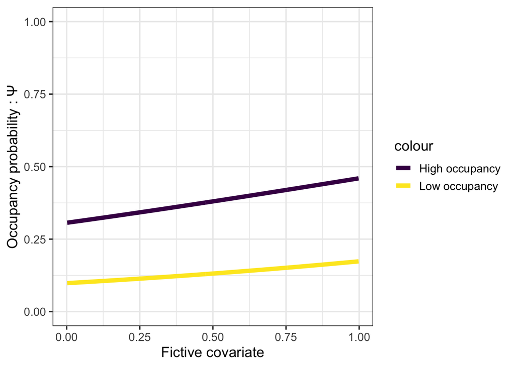

### Observation process

The observations are drawn either from a Bernoulli distribution with parameter $p$ or a multinomial distribution depending on two detection probability $p_1$ and $p_2$ for the integrated occupancy model. We wrote $p$ as a logistic function of a sampling effort covariate $\mbox{seff}$:

$$\mbox{logit}(p) = \beta_{0} + \beta_{1} \; \mbox{seff}$$

where $\beta_{0}$ and $\beta_{1}$ are unknown parameters that need to be estimated.

We considered two sets of values for the beta’s:

- $\beta_0 = -0.1$ and $\beta_1 = 0.16$ that led to $p$ approx. equal to 0.5
- $\beta_0 = 1.8$ and $\beta_1 = 0.6$ that led to $p$ approx. equal to 0.8

We used the `sim_obs_cov()` function to simulate the $y$ vector that contains the detections/non-detections.

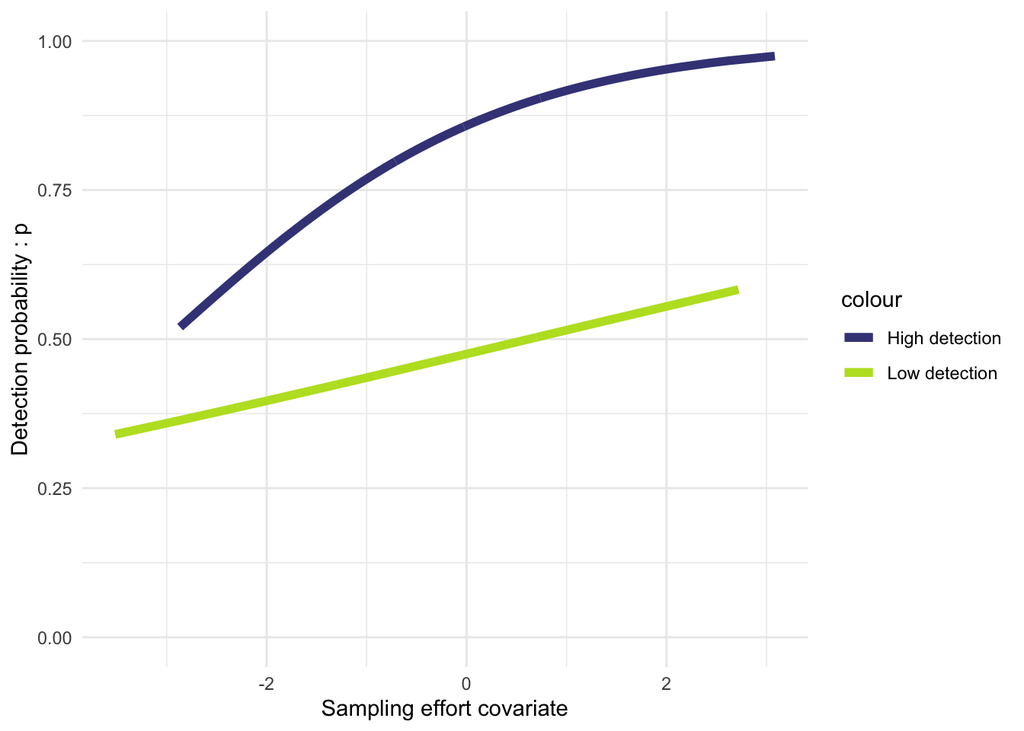

We simulated 4 different sampling occasions for repeated-visit occupancy. For single-visit occupancy, we formatted the data as described in the Methods section. For the sampling effort at site $i$, we summed the sampling effort over the 4 sampling occasions at site $i$, with `seff_sv <- apply(seff_rv,1,sum)`. For the detection/non-detection matrix, we considered the site as occupied if the species was detected at least once over the 4 sampling occasions, with `y_sv <- apply(y_rv,1,max)`.

## Models

We fitted 4 different occupancy models:

- Repeated-visit (RV) single-method occupancy model (SOM) with low detection probability
- Single-visit (SV) single-method occupancy model (SOM) with low detection probability
- Repeated-visits integrated occupancy model (IOM RV), in which we combined two datasets into an integrated occupancy framework
- Single-visit integrated occupancy model (IOM SV)

**Note that for the integrated occupancy, we combined datasets generated from the same $z$ ecological states with two different detection probabilities, i.e. we combined one monitoring with 0.5 detection probability (i.e. ‘low $p$’), and one monitoring with 0.8 detection probability (i.e. ‘high $p$’).**

## Scenarios

We considered 2 ecological scenarios depending on either the size of the study area or the value of occupancy probability:

- 100 sites with low occupancy, $\psi = 0.1$
- 100 sites with high occupancy, $\psi = 0.3$

For each scenario, we ran 100 simulations and fitted the 4 occupancy models.

## Performances

To compare the performances of the different occupancy models we calculated the relative bias (RB), and the root mean square error (RMSE) over the `S = 100` simulations :

- Relative bias: $RB = \frac{1}{S} \sum_{1}^{S} \frac{(\widehat{\theta}_{s}-\theta)}{\theta}$
- Root Mean Square Error: $RMSE = \sqrt{ \frac{1}{S} \sum_{1}^{S} (\widehat{\theta}_{s}-\theta)^2}$

## R codes

R functions to simulate the data and run the simulations

```r
# load functionS
sim_state_cov <- function(nb_sites=nsites,init_occ = covparam, covenv = covenv){

  # define various quantities
  R = nb_sites # number of sites

  l.psi <- init_occ[1] + init_occ[2] * covenv + init_occ[3] * covenv * covenv
  psi1 <-  1 / ( 1 + exp( -l.psi ))# quadratic relation of the covariate with initial occupancy

  # pre-allocate memory
  site <- 1:R # Sites

  z <- array(dim = c(R)) # Expected and realized occurrence

  # define state process
  # first year/season
  z <- rbinom(R, 1, psi1) # Initial occupancy state


  return(z)
}
sim_obs_cov <- function(z=z, nb_occ = nocc,Seff, obsparam = obsparam){

  # define various quantities
  R = length(z) # number of sites
  K = nb_occ # number of occasions

  y <- array(NA, dim = c(R,K))
  p <- array(NA, dim = c(R,K))

  # define observation process

  for(i in 1:R){
    for(k in 1:K){

      l.p <- obsparam[1] + obsparam[2] * Seff[i,k] + obsparam[3] * Seff[i,k] * Seff[i,k]# quadratic relation of the covariate with initial occupancy

      p[i,k] <- ( 1 / ( 1 + exp(- l.p )))

      prob <- z[i] * p[i,k]
      y[i,k] <- rbinom(1,1, prob= prob)
    } #k
  } #i


  # format data
  return(y)
}
loop <- function(nsites, nocc, nsim, covparam, obsparam1,obsparam2, Seff, Seff2, Covenv){


  #### allocate memories for posterior estimates ####

  p_i <- rep(NA, nsim)
  psi_i <- rep(NA, nsim)

  bcov_i <- rep(NA, nsim)
  bseff_i <- rep(NA, nsim)

  p_ii <- rep(NA, nsim)
  psi_ii <- rep(NA, nsim)

  bcov_ii <- rep(NA, nsim)
  bseff_ii<- rep(NA, nsim)

  p1_iii <- rep(NA, nsim)
  p2_iii <- rep(NA, nsim)
  psi_iii <-rep(NA, nsim)

  bcov_iii <- rep(NA, nsim)
  bseff1_iii<- rep(NA, nsim)
  bseff2_iii<- rep(NA, nsim)

  p1_iv <- rep(NA, nsim)
  p2_iv <- rep(NA, nsim)
  psi_iv <-rep(NA, nsim)

  bcov_iv <- rep(NA, nsim)
  bseff1_iv<- rep(NA, nsim)
  bseff2_iv<- rep(NA, nsim)

  # bis high p
  p_ibis <- rep(NA, nsim)
  psi_ibis <- rep(NA, nsim)

  bcov_ibis <- rep(NA, nsim)
  bseff_ibis <- rep(NA, nsim)

  p_iibis <- rep(NA, nsim)
  psi_iibis <- rep(NA, nsim)

  bcov_iibis <- rep(NA, nsim)
  bseff_iibis<- rep(NA, nsim)

  # allocate memory to saved parameters

  rbpsi_i    <- rep(NA, nsim)
  rmsepsi_i   <- rep(NA, nsim)
  rbcov_i     <- rep(NA, nsim)
  rmsecov_i <- rep(NA, nsim)
  rbp_i     <- rep(NA, nsim)
  rmsep_i    <- rep(NA, nsim)

  rbseff_i    <- rep(NA, nsim)
  rmseseff_i  <- rep(NA, nsim)
  # ii<- rep(NA, nsim)
  rbpsi_ii    <- rep(NA, nsim)
  rmsepsi_ii  <- rep(NA, nsim)

  rbcov_ii    <- rep(NA, nsim)
  rmsecov_ii  <- rep(NA, nsim)

  rbp_ii      <- rep(NA, nsim)
  rmsep_ii    <- rep(NA, nsim)

  rbseff_ii   <- rep(NA, nsim)
  rmseseff_ii <- rep(NA, nsim)

  # iii   <- rep(NA, nsim)
  rbpsi_iii   <- rep(NA, nsim)
  rmsepsi_iii <- rep(NA, nsim)

  rbcov_iii   <- rep(NA, nsim)
  rmsecov_iii <- rep(NA, nsim)

  rbp1_iii    <- rep(NA, nsim)
  rmsep1_iii  <- rep(NA, nsim)
  rbseff1_iii <- rep(NA, nsim)
  rmseseff1_iii<- rep(NA, nsim)

  rbp2_iii    <- rep(NA, nsim)
  rmsep2_iii  <- rep(NA, nsim)
  rbseff2_iii <- rep(NA, nsim)
  rmseseff2_iii<- rep(NA, nsim)
                         # iv
  rbpsi_iv    <- rep(NA, nsim)
  rmsepsi_iv  <- rep(NA, nsim)
  rbcov_iv    <- rep(NA, nsim)
  rmsecov_iv  <- rep(NA, nsim)
  rbp1_iv     <- rep(NA, nsim)
  rmsep1_iv   <- rep(NA, nsim)
  rbseff1_iv  <- rep(NA, nsim)
  rmseseff1_iv<- rep(NA, nsim)
  rbp2_iv     <- rep(NA, nsim)
  rmsep2_iv   <- rep(NA, nsim)
  rbseff2_iv  <- rep(NA, nsim)
  rmseseff2_iv<- rep(NA, nsim)

  # bis highp
  p_ibis <- rep(NA, nsim)
  psi_ibis <- rep(NA, nsim)

  bcov_ibis <- rep(NA, nsim)
  bseff_ibis <- rep(NA, nsim)

  p_iibis <- rep(NA, nsim)
  psi_iibis <- rep(NA, nsim)

  bcov_iibis <- rep(NA, nsim)
  bseff_iibis<- rep(NA, nsim)

  # parameters
  rbpsi_ibis    <- rep(NA, nsim)
  rmsepsi_ibis   <- rep(NA, nsim)
  rbcov_ibis     <- rep(NA, nsim)
  rmsecov_ibis <- rep(NA, nsim)
  rbp_ibis     <- rep(NA, nsim)
  rmsep_ibis    <- rep(NA, nsim)

  rbseff_ibis    <- rep(NA, nsim)
  rmseseff_ibis  <- rep(NA, nsim)
  # ii<- rep(NA, nsim)
  rbpsi_iibis    <- rep(NA, nsim)
  rmsepsi_iibis  <- rep(NA, nsim)

  rbcov_iibis    <- rep(NA, nsim)
  rmsecov_iibis  <- rep(NA, nsim)

  rbp_iibis      <- rep(NA, nsim)
  rmsep_iibis    <- rep(NA, nsim)

  rbseff_iibis   <- rep(NA, nsim)
  rmseseff_iibis <- rep(NA, nsim)

  # JAGS models

  sink("Sim_occu_cov.jags")
  cat("
    model {

    # Specify priors

    alpha.psi ~ dnorm(0,0.444) # intercept occupancy
    alpha.p ~ dnorm(0,0.444) # intercept detection

    beta.cov ~ dnorm(0,0.444) # slope cov effect
    beta.qcov ~ dnorm(0,0.444)  # slope quadratic cov effect

    beta.seff ~ dnorm(0,0.444)  # slope Sampling effort effect
    beta.qseff ~ dnorm(0,0.444) # slope quadratic sampling effort

    beta.occ2 ~ dnorm(0,0.444) # occasion effect
    beta.occ3 ~ dnorm(0,0.444) # occasion effect
    beta.occ4 ~ dnorm(0,0.444) # occasion effect


    ### Ecological states

    for (i in 1:nsite){

      z[i] ~ dbern(muZ[i])
      logit(muZ[i]) <- l.muZ[i]

      l.muZ[i] <- alpha.psi + beta.cov * covenv[i] + beta.qcov * covenv[i] * covenv[i]

    } # i

    # Observation model

    for (i in 1:nsite){

      for (k in 1:nocc){

          logit(p[i,k]) <- -l.p[i,k]
          l.p[i,k] <- alpha.p + beta.seff * Seff[i,k] + beta.qseff * Seff[i,k] * Seff[i,k] + beta.occ2 * equals(k,2) + beta.occ3 * equals(k,3) + beta.occ4 * equals(k,4)


    y[i,k] ~ dbern(z[i]*p[i,k])

      } #k
    } #i


    }
    ",fill = TRUE)
  sink()

  sink("sim_IOM_cov.jags")
  cat("
    model {
    # priors

    alpha.psi ~ dnorm(0,0.444) # occupancy intercept
    alpha.p1 ~ dnorm(0,0.444) # detection samm intercept
    alpha.p2 ~ dnorm(0,0.444) # detection gdegem intercept

    # slope priors

    beta.cov ~ dnorm(0,0.444) # slope cov effect
    beta.qcov ~ dnorm(0,0.444)  # slope quadratic cov effect

    beta.seff1 ~ dnorm(0,0.444) # slope Sampling effort effect
    beta.qseff1 ~ dnorm(0,0.444)    # slope quadratic sampling effort

    beta.seff2 ~ dnorm(0,0.444) # slope Sampling effort effect
    beta.qseff2 ~ dnorm(0,0.444)    # slope quadratic sampling effort
```

```r
    beta.occ2 ~ dnorm(0,0.444) # occasion effect
    beta.occ3 ~ dnorm(0,0.444) # occasion effect
    beta.occ4 ~ dnorm(0,0.444) # occasion effect

    # NO COV

    # Ecological state

    for (i in 1:nsite){

       z[i] ~ dbern(muZ[i])
      logit(muZ[i]) <- l.muZ[i]

        l.muZ[i] <- alpha.psi + beta.cov * covenv[i] + beta.qcov * covenv[i] * covenv[i]

      for (j in 1:nocc){

        # p1
        logit(p1[i,j]) <- lp1[i,j]
        lp1[i,j] <- alpha.p1  + beta.seff1 * Seff1[i,j] + beta.seff1 * Seff1[i,j] * Seff1[i,j] + beta.occ2 * equals(j,2) + beta.occ3 * equals(j,3) + beta.occ4 * equals(j,4)

         # p2
        logit(p2[i,j]) <- lp2[i,j]
        lp2[i,j] <- alpha.p2 + beta.seff2 * Seff2[i,j] + beta.qseff2 * Seff2[i,j] * Seff2[i,j] + beta.occ2 * equals(j,2) + beta.occ3 * equals(j,3) + beta.occ4 * equals(j,4)


        mu.p[i,j,1] <- 1 - z[i] + z[i] * (1 - p1[i,j]) * (1 - p2[i,j]) # P(O=0) : no detection
        mu.p[i,j,2] <- z[i] * p1[i,j] * (1 - p2[i,j])                  # P(O=1) : detection by samm only
        mu.p[i,j,3] <- z[i] * p2[i,j] * (1 - p1[i,j])                 # P(O=2) : detection by gdegem only
        mu.p[i,j,4] <- z[i] * p1[i,j] * p2[i,j]                        # P(O=3) : detection by both samm and gdegem

        y[i,j] ~ dcat(mu.p[i,j,])
    } #j
    } #i
    }
    ", fill = TRUE)
  sink()

  #### loop over nsim ####
  for( s in 1:nsim){

    # simulate datasets s

    z <- sim_state_cov(nb_sites = nsites, covenv= covenv, init_occ= covparam)
    y <- sim_obs_cov(z,nocc,Seff= Seff, obsparam= obsparam1)

    y1 <- y # the first detection dataset
    p1 <- obsparam1
    p2 <- obsparam2
    y2bis <- y2 <- sim_obs_cov(z,nocc,obsparam = obsparam2, Seff =Seff2) # another dataset with different p
    y2bis[y2>0] <- 2
    y_int <- y1 + y2bis # 0 -> no detection, 1 -> detection by monitoring 1, 2-> detection by 2, 3 -> detection by both methods



    # perform analysis

    # Specify MCMC settings one for all
    ni <-  4000
    nb <- 1000
    nc <- 1

    #### i)  One monitoring RV low p ####


    # Bundle data

    win.data <- list(y = y1,nsite = dim(y)[1], nocc = dim(y)[2], Seff = Seff, covenv = covenv)

    # Initial values
    zst <- apply(y, 1, max) # Observed occurrence as inits for z
    psi = covparam[1]    # sum(z)/nsites
    p = obsparam1[1]
    bcov <- covparam[2]
    bseff <- obsparam1[2]

    inits <- function(){ list(z = zst, alpha.psi = psi, alpha.p= p, beta.cov = bcov, beta.seff= bseff)}

    # Parameters monitored
    params <- c( "alpha.p","alpha.psi", "beta.cov", "beta.qcov","beta.seff" ,"beta.qseff")


    # Call JAGS from R (BRT 3 min)
    out <- jags(win.data, inits, params, "Sim_occu_cov.jags", n.chains = nc, n.iter = ni, n.burnin = nb, working.directory = getwd())

    # denplot(out)
    # head(out$BUGSoutput$summary)

    # save results

    # intercept
    p_i[s] <- out$BUGSoutput$mean$alpha.p
    psi_i[s] <- out$BUGSoutput$mean$alpha.psi

    # slope linear estimate (Q: do we have to save the quadratic estimates-)

    bcov_i[s] <-    out$BUGSoutput$mean$beta.cov
    bseff_i[s] <-   out$BUGSoutput$mean$beta.seff

    #### i bis )  One monitoring RV high p ####


    # Bundle data

    win.data <- list(y = y2,nsite = dim(y2)[1], nocc = dim(y2)[2], Seff = Seff2, covenv = covenv)


    # Initial values
    zst <- apply(y2, 1, max)    # Observed occurrence as inits for z
    psi = covparam[1]   # sum(z)/nsites
    p = obsparam2[1]
    bcov <- covparam[2]
    bseff <- obsparam2[2]

    inits <- function(){ list(z = zst, alpha.psi = psi, alpha.p= p, beta.cov = bcov, beta.seff= bseff)}

    # Parameters monitored
    params <- c( "alpha.p","alpha.psi", "beta.cov", "beta.qcov","beta.seff" ,"beta.qseff")


    # Call JAGS from R (BRT 3 min)
    out <- jags(win.data, inits, params, "Sim_occu_cov.jags", n.chains = nc, n.iter = ni, n.burnin = nb, working.directory = getwd())

   # head(out$BUGSoutput$summary)

    # save results

    # intercept
    p_ibis[s] <- out$BUGSoutput$mean$alpha.p
    psi_ibis[s] <- out$BUGSoutput$mean$alpha.psi

    # slope linear estimate (Q: do we have to save the quadratic estimates-)

    bcov_ibis[s] <- out$BUGSoutput$mean$beta.cov
    bseff_ibis[s] <- out$BUGSoutput$mean$beta.seff


     #### ii)  One monitoring SV ####

    # same model jags than i)

    # Bundle data

    ysv <-  matrix(apply(y,1,max))
    Seffsv <- matrix(apply(Seff,1,sum))

    win.data <- list(y = ysv,nsite = dim(ysv)[1], nocc = dim(ysv)[2], Seff = Seffsv, covenv = covenv)


    # Initial values
    zst <- apply(ysv, 1, max)   # Observed occurrence as inits for z
    psi = covparam[1]   # sum(z)/nsites
    p = obsparam1[1]
    bcov <- covparam[2]
    bseff <- obsparam1[2]

    inits <- function(){ list(z = zst, alpha.psi = psi, alpha.p= p, beta.cov = bcov, beta.seff= bseff)}


    # Parameters monitored
    params <- c("z", "alpha.p","alpha.psi", "beta.cov", "beta.seff","beta.qcov", "beta.qseff")


    # Call JAGS from R (BRT 3 min)

    out <- jags(win.data, inits, params, "Sim_occu_cov.jags", n.chains = nc,  n.iter = ni,  n.burnin = nb, working.directory = getwd())

    # head(out$BUGSoutput$summary)

    p_ii[s] <- out$BUGSoutput$mean$alpha.p
    psi_ii[s] <- out$BUGSoutput$mean$alpha.psi

    # slope linear estimate (Q: do we have to save the quadratic estimates-)

    bcov_ii[s] <- out$BUGSoutput$mean$beta.cov
    bseff_ii[s] <- out$BUGSoutput$mean$beta.seff

    #### ii bis )  One monitoring SV high p ####

    # same model jags than i)

    # Bundle data

    y2sv <-  matrix(apply(y2,1,max))

    Seff2sv <- matrix(apply(Seff2,1,max))
    win.data <- list(y = y2sv,nsite = dim(y2sv)[1], nocc = dim(y2sv)[2], Seff = Seff2sv, covenv = covenv)


    # Initial values
    zst <- apply(y2sv, 1, max)  # Observed occurrence as inits for z
    psi = covparam[1]   # sum(z)/nsites
    p = obsparam2[1]
    bcov <- covparam[2]
    bseff <- obsparam2[2]

    inits <- function(){ list(z = zst, alpha.psi = psi, alpha.p= p, beta.cov = bcov, beta.seff= bseff)}
```

```r
    # Parameters monitored
    params <- c("z", "alpha.p","alpha.psi", "beta.cov", "beta.seff")


    # Call JAGS from R (BRT 3 min)
    out <- jags(win.data, inits, params, "Sim_occu_cov.jags", n.chains = nc,  n.iter = ni,  n.burnin = nb, working.directory = getwd())


    p_iibis[s] <- out$BUGSoutput$mean$alpha.p
    psi_iibis[s] <- out$BUGSoutput$mean$alpha.psi

    # slope linear estimate (Q: do we have to save the quadratic estimates-)

    bcov_iibis[s] <- out$BUGSoutput$mean$beta.cov
    bseff_iibis[s] <- out$BUGSoutput$mean$beta.seff


    #### iii)  Two monitoring RV ####

    # we work with y_int
    win.data <- list(y = y_int+1,nsite = dim(y_int)[1], nocc = dim(y_int)[2], covenv = covenv, Seff1 = Seff1, Seff2 = Seff2)


    # Initial values
    zst <- apply(y_int, 1, max)
    zst[zst>0] <- 1 # Observed occurrence as inits for z
    psi = covparam[1]   # sum(z)/nsites
    p1 = obsparam1[1]
    p2 = obsparam2[1]
    bcov <- covparam[2]
    bseff1 <- obsparam1[2]
    bseff2 <- obsparam2[2]

    inits <- function(){ list(z = zst, alpha.psi = psi, alpha.p1=p1, alpha.p2=p2,beta.cov = bcov, beta.seff1= bseff1, beta.seff2= bseff2)}

    # Parameters monitored
    params <- c("z", "alpha.p1","alpha.psi","alpha.p2","beta.cov","beta.qcov","beta.seff1","beta.seff2","beta.qseff1","beta.qseff2")


    # Call JAGS from R (BRT 3 min)
    out <- jags(win.data, inits, params, "sim_IOM_cov.jags", n.chains = nc,  n.iter = ni,n.burnin = nb, working.directory = getwd())

    p1_iii[s] <-out$BUGSoutput$mean$alpha.p1
    p2_iii[s] <- out$BUGSoutput$mean$alpha.p2

    psi_iii[s] <- out$BUGSoutput$mean$alpha.psi

    # save results slope

    bseff1_iii[s] <-out$BUGSoutput$mean$beta.seff1

    bseff2_iii[s] <- out$BUGSoutput$mean$beta.seff2

    bcov_iii[s] <- out$BUGSoutput$mean$beta.cov


    #### iv)  Two monitoring SV ####

    # same model jags than iii)

    # Bundle data

    y1sv <-  matrix(apply(y1,1,max))
    y2sv <-  matrix(apply(y2,1,max))
    y2sv[y2sv>0] <- 2

    ysv_int <- y1sv + y2sv

    Seff1sv <-  matrix(apply(Seff1,1,sum))
    Seff2sv <-  matrix(apply(Seff2,1,sum))

    win.data <- list(y = ysv_int+1,nsite = dim(ysv_int)[1], nocc = dim(ysv_int)[2], Seff1= Seff1sv, Seff2 = Seff2sv, covenv = covenv)

    # Initial values
    zst <- apply(ysv_int, 1, max)
    zst[zst>0] <- 1 # Observed occurrence as inits for z
    psi = covparam[1]   # sum(z)/nsites
    p1 = obsparam1[1]
    p2 = obsparam2[1]
    bcov <- covparam[2]
    bseff1 <- obsparam1[2]
    bseff2 <- obsparam2[2]

    inits <- function(){ list(z = zst, alpha.psi = psi, alpha.p1=p1, alpha.p2=p2,beta.cov = bcov, beta.seff1= bseff1, beta.seff2= bseff2)}

    # Parameters monitored
    params <- c("z", "alpha.p1","alpha.psi","alpha.p2","beta.cov","beta.qcov","beta.seff1","beta.seff2","beta.qseff1","beta.qseff2")


    # Call JAGS from R (BRT 3 min)
    out <- jags(win.data, inits, params, "sim_IOM_cov.jags", n.chains = nc,  n.iter = ni, n.burnin = nb, working.directory = getwd())

    p1_iv[s] <-out$BUGSoutput$mean$alpha.p1
    p2_iv[s] <- out$BUGSoutput$mean$alpha.p2

    psi_iv[s] <-out$BUGSoutput$mean$alpha.psi

    # save results slope

    bseff1_iv[s] <-out$BUGSoutput$mean$beta.seff1
    bseff2_iv[s] <- out$BUGSoutput$mean$beta.seff2
    bcov_iv[s] <- out$BUGSoutput$mean$beta.cov

    # calcul and save RMSE and RB

    # i
    rbpsi_i[s]        <- (psi_i[s]-covparam[1])/covparam[1]   # RB alpha.psi
    rmsepsi_i[s]      <- (psi_i[s] - covparam[1])^2 # RMSE alpha.psi

    rbcov_i[s]        <- (bcov_i[s]-covparam[2])/covparam[2]   # RB cov
    rmsecov_i[s]      <- (bcov_i[s] - covparam[2])^2 # RMSE cov

    rbp_i[s]          <- (p_i[s]-obsparam1[1])/obsparam1[1]       # RB alpha p
    rmsep_i[s]        <- (p_i[s] - obsparam1[1])^2 # RMSE alpha p

    rbseff_i[s]       <- (bseff_i[s]-obsparam1[2])/obsparam1[2]   # RB obs
    rmseseff_i[s]     <- (bseff_i[s] - obsparam1[2])^2 # RMSE obs


    # ii
    rbpsi_ii[s]       <- (psi_ii[s]-covparam[1])/covparam[1]   # RB alpha.psi
    rmsepsi_ii[s]     <- (psi_ii[s] - covparam[1])^2 # RMSE alpha.psi

    rbcov_ii[s]       <- (bcov_ii[s]-covparam[2])/covparam[2]  # RB cov
    rmsecov_ii[s]     <- (bcov_ii[s] - covparam[2])^2 # RMSE cov

    rbp_ii[s]         <- (p_ii[s]-obsparam1[1])/obsparam1[1]      # RB alpha p
    rmsep_ii[s]       <- (p_ii[s] - obsparam1[1])^2 # RMSE alpha p

    rbseff_ii[s]      <- (bseff_ii[s]-obsparam1[2])/obsparam1[2]   # RB obs
    rmseseff_ii[s]    <- (bseff_ii[s] - obsparam1[2])^2 # RMSE obs


    # iii
    rbpsi_iii[s]      <- (psi_iii[s]-covparam[1])/covparam[1]  # RB alpha.psi
    rmsepsi_iii[s]    <- (psi_iii[s] - covparam[1])^2 # RMSE alpha.psi

    rbcov_iii[s]      <- (bcov_iii[s]-covparam[2])/covparam[2]   # RB cov
    rmsecov_iii[s]    <- (bcov_iii[s] - covparam[2])^2 # RMSE cov

    rbp1_iii[s]       <- (p1_iii[s]-obsparam1[1])/obsparam1[1]        # RB alpha p
    rmsep1_iii[s]     <- (p1_iii[s] - obsparam1[1])^2 # RMSE alpha p

    rbseff1_iii[s]     <- (bseff1_iii[s]-obsparam1[2])/obsparam1[2]  # RB obs
    rmseseff1_iii[s]   <- (bseff1_iii[s] - obsparam1[2])^2 # RMSE obs

    rbp2_iii[s]        <- (p2_iii[s]-obsparam2[1])/obsparam2[1]       # RB alpha p
    rmsep2_iii[s]      <- (p2_iii[s] - obsparam2[1])^2 # RMSE alpha p

    rbseff2_iii[s]     <- (bseff2_iii[s]-obsparam2[2])/obsparam2[2]  # RB obs
    rmseseff2_iii[s]   <- (bseff2_iii[s] - obsparam2[2])^2 # RMSE obs


    # iv
    rbpsi_iv[s]        <- (psi_iv[s]-covparam[1])/covparam[1]  # RB alpha.psi
    rmsepsi_iv[s]      <- (psi_iv[s] - covparam[1])^2 # RMSE alpha.psi

    rbcov_iv[s]        <- (bcov_iv[s]-covparam[2])/covparam[2]   # RB cov
    rmsecov_iv[s]      <- (bcov_iv[s] - covparam[2])^2 # RMSE cov

    rbp1_iv[s]         <- (p1_iv[s]-obsparam1[1])/obsparam1[1]        # RB alpha p
    rmsep1_iv[s]       <- (p1_iv[s] - obsparam1[1])^2 # RMSE alpha p

    rbseff1_iv[s]      <- (bseff1_iv[s]-obsparam1[2])/obsparam1[2]   # RB obs
    rmseseff1_iv[s]    <- (bseff1_iv[s] - obsparam1[2])^2 # RMSE obs
```

```r
    rbp2_iv[s]         <- (p2_iv[s]-obsparam2[1])/obsparam2[1]       # RB alpha p
    rmsep2_iv[s]       <- (p2_iv[s] - obsparam2[2])^2 # RMSE alpha p

    rbseff2_iv[s]      <- (bseff2_iv[s]-obsparam2[2])/obsparam2[2]   # RB obs
    rmseseff2_iv[s]    <- (bseff2_iv[s] - obsparam2[2])^2 # RMSE obs

    # ibis
    rbpsi_ibis[s]        <- (psi_ibis[s]-covparam[1])/covparam[1]   # RB alpha.psi
    rmsepsi_ibis[s]      <- (psi_ibis[s] - covparam[1])^2 # RMSE alpha.psi

    rbcov_ibis[s]        <- (bcov_ibis[s]-covparam[2])/covparam[2]   # RB cov
    rmsecov_ibis[s]      <- (bcov_ibis[s] - covparam[2])^2 # RMSE cov

    rbp_ibis[s]          <- (p_ibis[s]-obsparam2[1])/obsparam2[1]       # RB alpha p
    rmsep_ibis[s]        <- (p_ibis[s] - obsparam2[1])^2 # RMSE alpha p

    rbseff_ibis[s]       <- (bseff_ibis[s]-obsparam2[2])/obsparam2[2]   # RB obs
    rmseseff_ibis[s]     <- (bseff_ibis[s] - obsparam2[2])^2 # RMSE obs


    # ii bis
    rbpsi_iibis[s]       <- (psi_iibis[s]-covparam[1])/covparam[1]   # RB alpha.psi
    rmsepsi_iibis[s]     <- (psi_iibis[s] - covparam[1])^2 # RMSE alpha.psi

    rbcov_iibis[s]       <- (bcov_iibis[s]-covparam[2])/covparam[2]  # RB cov
    rmsecov_iibis[s]     <- (bcov_iibis[s] - covparam[2])^2 # RMSE cov

    rbp_iibis[s]         <- (p_iibis[s]-obsparam2[1])/obsparam2[1]      # RB alpha p
    rmsep_iibis[s]       <- (p_iibis[s] - obsparam2[1])^2 # RMSE alpha p

    rbseff_iibis[s]      <- (bseff_iibis[s]-obsparam2[2])/obsparam2[2]   # RB obs
    rmseseff_iibis[s]    <- (bseff_iibis[s] - obsparam2[2])^2 # RMSE obs


  } # end for



  para <- data.frame("nsites" = nsites,"nocc" =  nocc, "nsim" = nsim, "covparam"= covparam, "obsparam1"= obsparam1,"obsparam2" = obsparam2)

  return(list(para, # i
              rbpsi_i,rmsepsi_i , rbcov_i ,
              rmsecov_i,
              rbp_i ,
              rmsep_i ,
              rbseff_i ,
              rmseseff_i ,
              # ii
              rbpsi_ii,
              rmsepsi_ii,
              rbcov_ii,
              rmsecov_ii,
              rbp_ii,
              rmsep_ii,
              rbseff_ii,
              rmseseff_ii ,
              # iii
              rbpsi_iii,
              rmsepsi_iii ,
              rbcov_iii,
              rmsecov_iii ,
              rbp1_iii,
              rmsep1_iii,
              rbseff1_iii ,
              rmseseff1_iii,
              rbp2_iii,
              rmsep2_iii,
              rbseff2_iii ,
              rmseseff2_iii,
              # iv
              rbpsi_iv ,
              rmsepsi_iv,
              rbcov_iv,
              rmsecov_iv,
              rbp1_iv,
              rmsep1_iv,
              rbseff1_iv,
              rmseseff1_iv,
              rbp2_iv ,
              rmsep2_iv,
              rbseff2_iv,
              rmseseff2_iv,
              # ibis
              rbpsi_ibis,rmsepsi_ibis , rbcov_ibis ,
              rmsecov_ibis,
              rbp_ibis ,
              rmsep_ibis ,
              rbseff_ibis ,
              rmseseff_ibis ,
              # iibis
              rbpsi_iibis,
              rmsepsi_iibis,
              rbcov_iibis,
              rmsecov_iibis,
              rbp_iibis,
              rmsep_iibis,
              rbseff_iibis,
              rmseseff_iibis))

} # endfunction
```

R code to run the analysis

```r
nsim = 100

nsites = 100
nocc = 4

covparam.3 <- c(-0.5,0.2,0) # psi = 0.3
covparam.1 <- c(-1.9,0.2,0) # psi = 0.1

covparam <- list(covparam.1 = c(-1.9,0.2,0),covparam.3 = c(-0.5,0.2,0))

obsparam <- c(-0.1,0.16,0) # p = 0.5
obsparam1 <- c(-0.1,0.16,0) # p = 0.5

obsparam2 <- c(1.8,0.6,0) # p = 0.8

# all simul for loop
res <- list()
i <- 0
t <- proc.time()
for(c in 1: length(covparam)){  #i <- i+1


    i <- i+1

    print(paste("obs",o))
    print(paste("cov",c))
    res[[i]] <- loop(nsites, nocc, nsim, covparam[[c]], obsparam1,obsparam2, Seff, Seff2, Covenv)


} # end c

run.time <- proc.time() - t


names(res[[1]]) <-  names(res[[2]]) <-  c("para", "rbpsi_i","rmsepsi_i" , "rbcov_i" ,
  "rmsecov_i",
  "rbp_i" ,
  "rmsep_i" ,
  "rbseff_i" ,
  "rmseseff_i" ,
  "rbpsi_ii",
  "rmsepsi_ii",
  "rbcov_ii",
  "rmsecov_ii",
  "rbp_ii",
  "rmsep_ii",
  "rbseff_ii",
  "rmseseff_ii" ,
  "rbpsi_iii",
  "rmsepsi_iii" ,
  "rbcov_iii",
  "rmsecov_iii" ,
  "rbp1_iii",
  "rmsep1_iii",
  "rbseff1_iii" ,
  "rmseseff1_iii",
  "rbp2_iii",
  "rmsep2_iii",
  "rbseff2_iii" ,
  "rmseseff2_iii",
  "rbpsi_iv",
  "rmsepsi_iv",
  "rbcov_iv",
  "rmsecov_iv",
  "rbp1_iv",
  "rmsep1_iv",
  "rbseff1_iv",
  "rmseseff1_iv",
  "rbp2_iv" ,
  "rmsep2_iv",
  "rbseff2_iv",
  "rmseseff2_iv",
  # bis
  "rbpsi_ibis","rmsepsi_ibis" , "rbcov_ibis" ,
  "rmsecov_ibis",
  "rbp_ibis" ,
  "rmsep_ibis" ,
  "rbseff_ibis" ,
  "rmseseff_ibis" ,
  "rbpsi_iibis",
  "rmsepsi_iibis",
  "rbcov_iibis",
  "rmsecov_iibis",
  "rbp_iibis",
  "rmsep_iibis",
  "rbseff_iibis",
  "rmseseff_iibis")

  names(res) <- c("occ1", "occ3")

save(res,run.time,file = "simIOM.rdata")
```

# Results

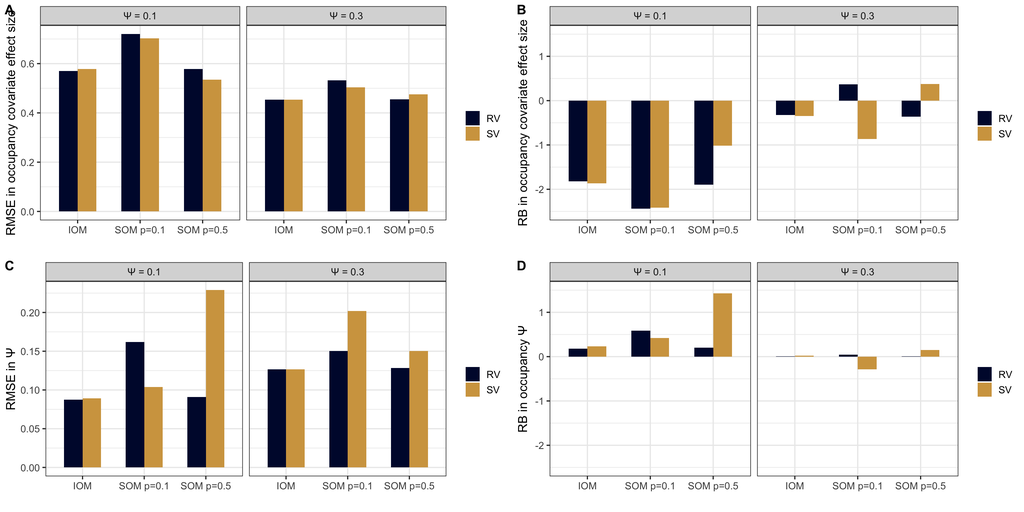

Fig. 3: RMSE and RB for covariate effect size, and predicted occupancy probability

## Predicted occupancy probabiltiy

When reconstructing the occupancy probability $\psi$ in Fig. 3C-D, integrated occupancy models exhibit better precision and bias than single-method occupancy models. Both single- and repeated-visits occupancy models seem to benefit from data integration in their performances. Note that RMSE plotting scale is different between Fig. 3A and 3C.

# Discussion

Our simulation study showed that integrated occupancy models improved precision and bias compared to occupancy models using the datasets in isolation. To be consistent with our manuscript, we reported performances of covariate effect size and predicted occupancy. To have a complete understanding of models performances, one might want to look at wider range of relationships, and observe all models parameters (e.g. intercept, sampling effort effect size on detection probability). Integrated occupancy, whether it is repeated-visit or single-visit, should help estimating detection probability with better precision.  
We noticed strong RMSE and RB for single-visit model compared to repeated-visit model when considering $\psi = 0.1$ and $p = 0.5$. Both results from Peach et al. (2017), and from our simulation study comparing single- and repeated-visit pointed out the limited performance of single-visit in the case of low occupancy. Integrated single-visit occupancy models help improving RMSE and RB.

Overall, our simulations underline that integrated single-visit occupancy models can be used to obtain reliable estimates of occupancy.

# References

Peach, M. A., Cohen, J. B., & Frair, J. L. (2017). Single-visit dynamic occupancy models: An approach to account for imperfect detection with Atlas data. In *Journal of Applied Ecology* (Nos. 6; Vol. 54, pp. 2033–2042). https://doi.org/10.1111/1365-2664.12925